# Exploratory Data Analysis of Known Exoplanets by Luke Tibbott

This data set was retrieved from the NASA Exoplanet Archive. An exoplanet is an extrasolar planet – that is, a planet that exists outside of earth’s solar system. The original data set has been pared down to 17 columns from 140+ columns.

When cleaning this dataset I was confronted with the issue of what to do with the large amount of null values in certain columns. Removing all the rows with nulls results in a tiny dataset, and imputing the values is very dangerous due to the possibility of assigning incorrect values. Most null values are due to how a particular data point was captured – different exoplanet discovery missions are simply incapable of capturing certain characteristics of an exoplanet. Nonetheless, any good data we can add to our dataset is valuable to our analysis, so I decided to keep the null values.

# Univariate Plots Section

```
##      pl_hostname     pl_letter                      pl_discmethod
##  KOI-351   :   8   b      :2759   Transit                  :2919
##  TRAPPIST-1:   7   c      : 606   Radial Velocity          : 673
##  HD 10180  :   6   d      : 210   Microlensing             :  60
##  HD 219134 :   6   e      :  76   Imaging                  :  44
##  HD 34445  :   6   f      :  28   Transit Timing Variations:   0
##  Kepler-11 :   6   g      :  11   Eclipse Timing Variations:   0
##  (Other)   :3657   (Other):   6   (Other)                  :   0
##     pl_pnum        pl_orbper         pl_orbsmax         pl_bmassj
##  Min.   :1.000   Min.   :      0   Min.   :5.80e-03   Min.   : 0.0002
##  1st Qu.:1.000   1st Qu.:      5   1st Qu.:6.00e-02   1st Qu.: 0.1600
##  Median :1.000   Median :     12   Median :1.25e-01   Median : 0.9200
##  Mean   :1.774   Mean   :   2454   Mean   :7.43e+00   Mean   : 2.5334
##  3rd Qu.:2.000   3rd Qu.:     42   3rd Qu.:7.20e-01   3rd Qu.: 2.5950
##  Max.   :8.000   Max.   :7300000   Max.   :2.50e+03   Max.   :55.5900
##                  NA's   :88        NA's   :1678       NA's   :2326
##     pl_radj          pl_dens             pl_name       st_optmag
##  Min.   :0.0300   Min.   : 0.030   11 Com b  :   1   Min.   : 0.85
##  1st Qu.:0.1390   1st Qu.: 0.411   11 UMi b  :   1   1st Qu.:11.70
##  Median :0.2050   Median : 0.975   14 And b  :   1   Median :13.77
##  Mean   :0.3602   Mean   : 2.494   14 Her b  :   1   Mean   :12.80
##  3rd Qu.:0.3030   3rd Qu.: 2.440   16 Cyg B b:   1   3rd Qu.:14.97
##  Max.   :6.9000   Max.   :77.700   18 Del b  :   1   Max.   :20.15
##  NA's   :753      NA's   :3312     (Other)   :3690   NA's   :111
##     st_dist          st_spster        st_age          st_mass
##  Min.   :   1.29   G      : 441   Min.   : 0.001   Min.   : 0.020
##  1st Qu.: 180.00   K      : 329   1st Qu.: 3.020   1st Qu.: 0.820
##  Median : 556.16   M      : 209   Median : 4.070   Median : 0.970
##  Mean   : 648.42   F      : 140   Mean   : 4.152   Mean   : 1.023
##  3rd Qu.: 892.00   A      :  11   3rd Qu.: 4.725   3rd Qu.: 1.130
##  Max.   :8500.00   (Other):   5   Max.   :12.400   Max.   :23.560
##  NA's   :318       NA's   :2561   NA's   :1814     NA's   :764
##     st_teff        pl_bmasse
##  Min.   :  575   Min.   :    0.066
##  1st Qu.: 5053   1st Qu.:   50.213
##  Median : 5600   Median :  292.404
##  Mean   : 5435   Mean   :  804.977
##  3rd Qu.: 5923   3rd Qu.:  824.732
##  Max.   :10900   Max.   :17668.170
##  NA's   :128     NA's   :2326
```

```
## 'data.frame':    3696 obs. of  17 variables:
##  $ pl_hostname  : Factor w/ 2787 levels "11 Com","11 UMi",..: 1 2 3 4 5 6 7 8 9 9 ...
##  $ pl_letter    : Factor w/ 8 levels "b","c","d","e",..: 1 1 1 1 1 1 1 1 1 2 ...
##  $ pl_discmethod: Factor w/ 10 levels "Transit","Radial Velocity",..: 2 2 2 2 2 2 4 2 2 2 ...
##  $ pl_pnum      : int  1 1 1 1 1 1 1 1 2 2 ...
##  $ pl_orbper    : num  326 516 186 1773 798 ...
##  $ pl_orbsmax   : num  1.29 1.53 0.83 2.93 1.66 ...
##  $ pl_bmassj    : num  19.4 14.74 4.8 4.66 1.78 ...
##  $ pl_radj      : num  NA NA NA NA NA NA NA NA NA NA ...
##  $ pl_dens      : num  NA NA NA NA NA NA NA NA NA NA ...
##  $ pl_name      : Factor w/ 3735 levels "11 Com b","11 UMi b",..: 1 2 3 4 5 6 7 8 9 10 ...
##  $ st_optmag    : num  4.74 5.02 5.23 6.61 6.25 ...
##  $ st_dist      : num  110.6 119.5 76.4 18.1 21.4 ...
##  $ st_spster    : Factor w/ 10 levels "A","B","F","G",..: 5 5 4 5 4 4 5 4 5 5 ...
##  $ st_age       : num  NA NA NA NA NA NA 0.005 6.92 2.7 2.7 ...
##  $ st_mass      : num  2.7 2.78 2.2 0.9 1.08 2.3 0.85 0.99 1.54 1.54 ...
##  $ st_teff      : num  4742 4213 4813 5338 5750 ...
##  $ pl_bmasse    : num  6166 4685 1526 1481 566 ...
```

This dataset has 17 variables and about 3700 observations.

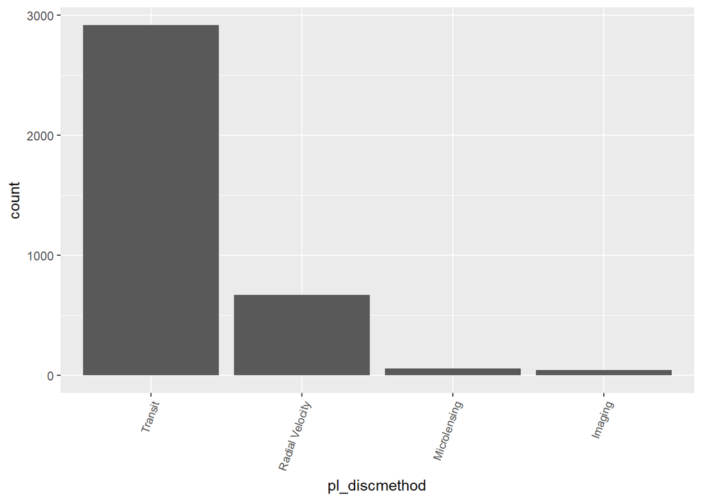

This bar chart shows us that transit and radial velocity methods of discovery are far and way the most popular methods for discovering exoplanets. Each of the other methods account for a very small proportion of all discovered exoplanets.

A couple notes and questions regarding the ‘discovery method’ variable analyzed in this project:

- The transit method relies on an exoplanet passing between Earth and a host star. The exoplanet blocks some of the star’s electromagnetic (EM) energy, thus confirming its existence. Perhaps a planet with a larger radius would block more EM energy and make it easier to discover?
- The radial velocity method looks at small changes in a star’s motion (eg whether the star is moving towards earth or away from Earth) to infer the existence of a planet. I wonder if more massive planets affect the motion of stars more, making it easier to discover more massive planets with this method?
- Microlensing relies on a magnification effect from a massive and very distant object to allow the observation of objects that don’t emit much electromagnetic energy, like a planet. What planetary attribute would lend itself to more planets being discovered this way?
- Imaging relies on us being able to directly see a planet. Perhaps planets are very close are discovered using imaging more frequently.
- The six other methods of discovering planets will not be explored in this analysis.

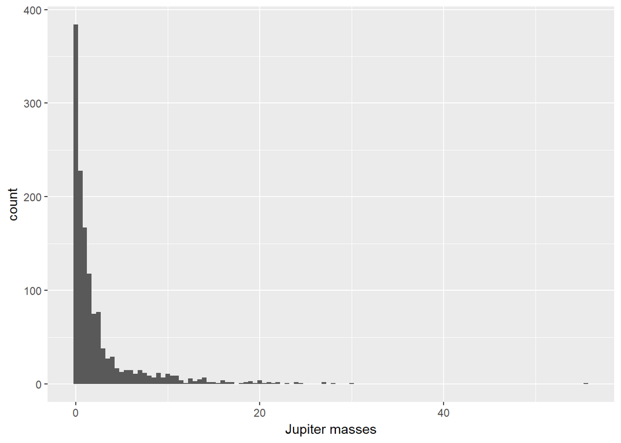

This plot shows us that a large number of planets are very close to 0 Jupiter masses (although none of them are exactly 0). This would lead me to believe these planets are not gas giants with huge mass and huge radius, but perhaps small, rocky planets. I would guess the planets with higher mass are gas giants. We can take a look at planet radius later on to see if these planets’ radii match up with the large numbers we’d expect from gas giants.

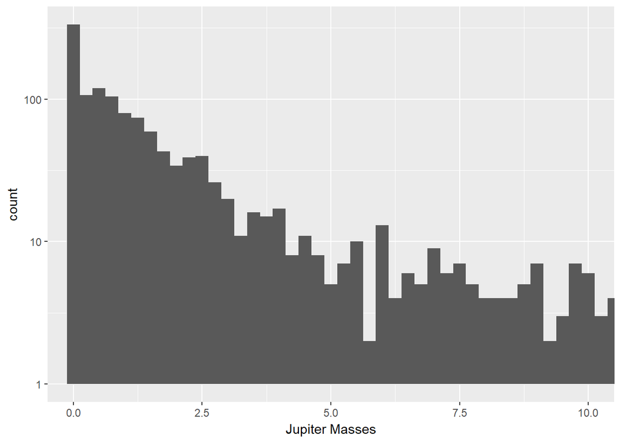

The log-10 adjusted graph with a smaller x-axis gives us a better idea of how planetary mass is distributed near 0 Jupiter masses. Again, we see a heavily right skewed distribution.

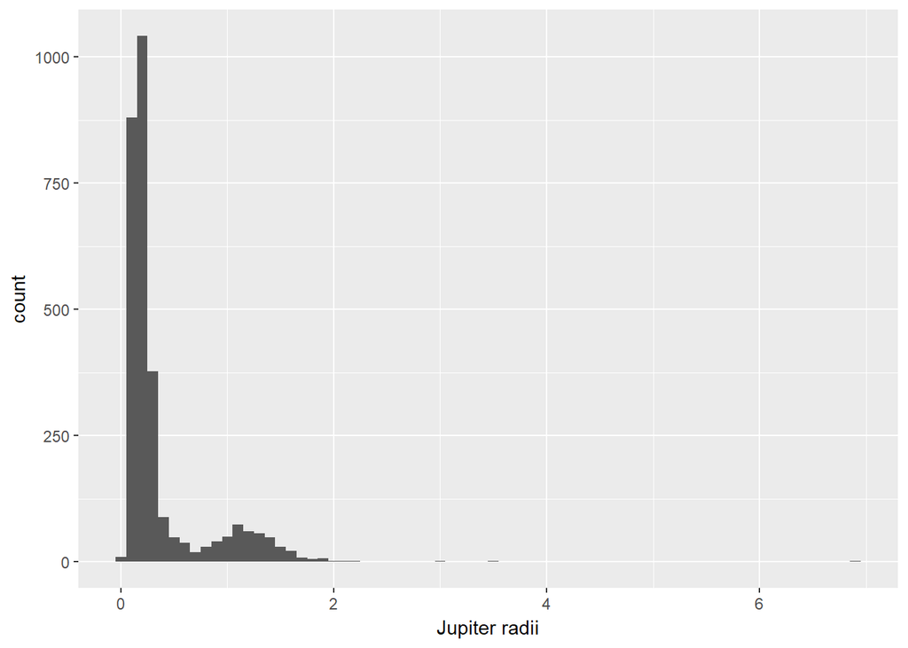

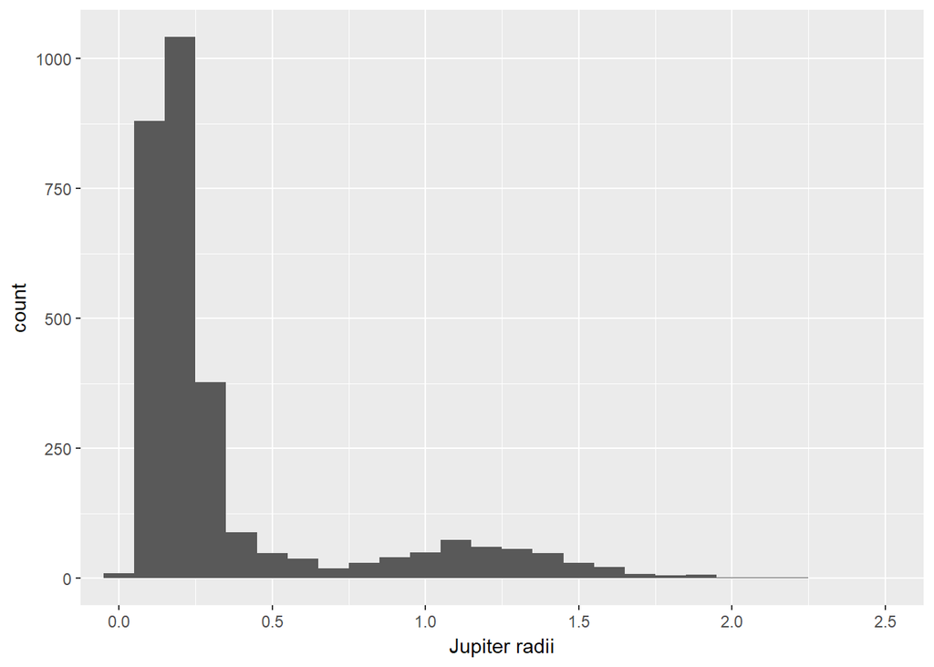

Most of the planets are less than .25 Jupiter radii, but there is a small peak a little over 1 Jupiter radius. I expected the planets’ radii to be be much higher after seeing the mass plot. This makes me think that many of the planets have a high density.

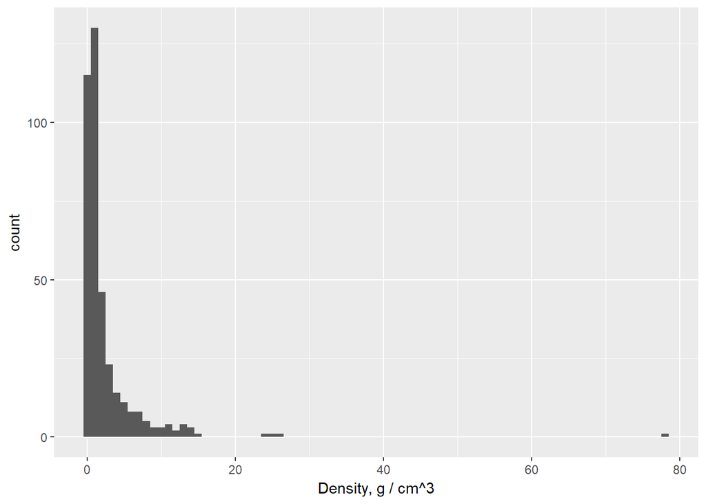

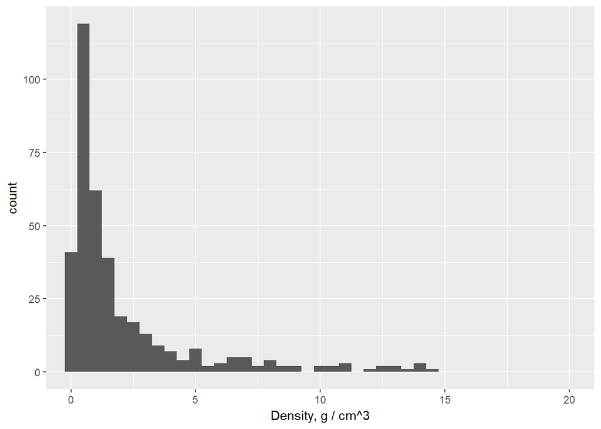

As suspected, we do see a bit more variance in density, but the relationship between mass, radius, and density needs to be investigated more. Unfortunately we have significantly less data on density than on mass and radius.

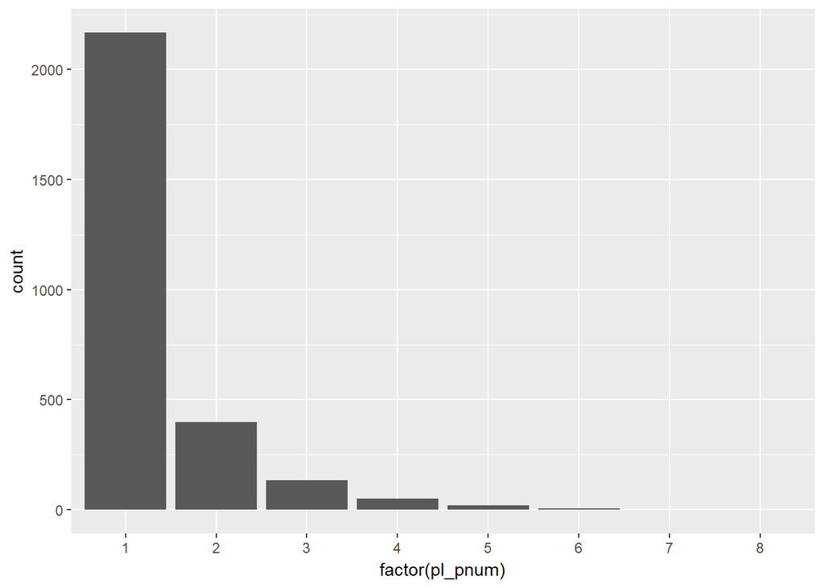

Most planetary systems we’ve discovered have only one planet. I’m interested to see if certain discovery methods lend themselves to discovering systems with more or less planets in them.

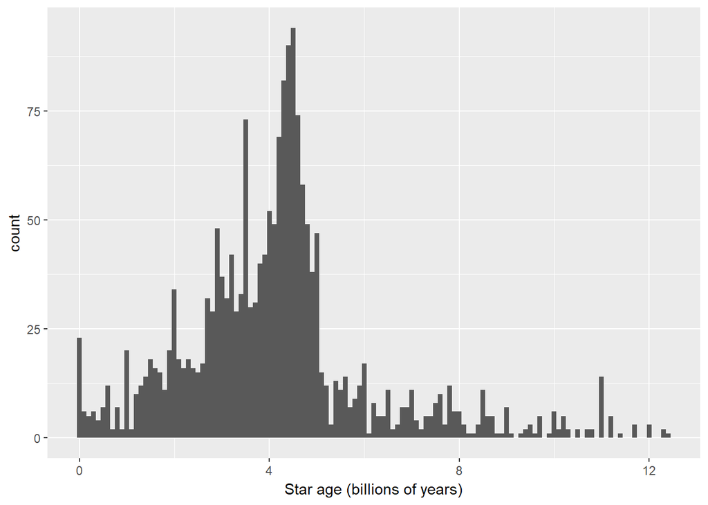

```
##    Min. 1st Qu.  Median    Mean 3rd Qu.    Max.    NA's
##   0.001   3.020   4.070   4.152   4.725  12.400    1814
```

The distribution of parent stars is certainly unimodal although perhaps not quite normal, with a clear peak a bit older than 4 billion years old, and a higher concentration of stars between 0 and 4.5 billion years old than stars between 4.5 and 12 billion years old. This could indicate a number of things, including our current detection methods being biased towards finding planets orbiting younger stars, or perhaps younger stars are more likely to host planets.

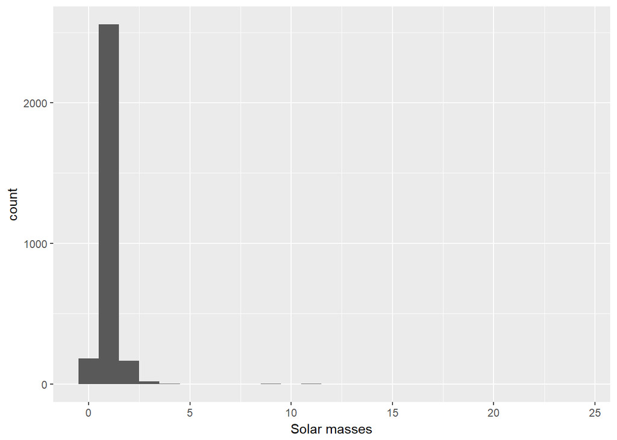

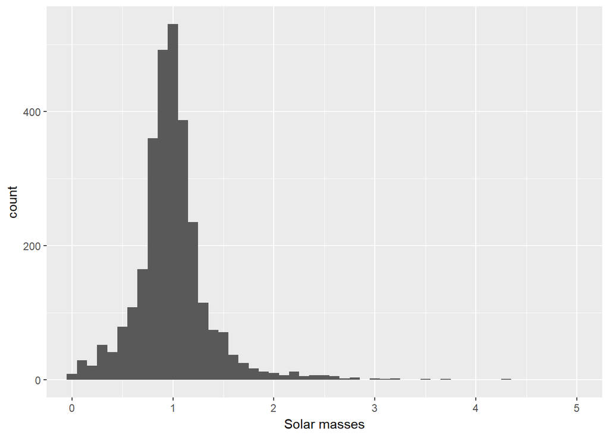

The stars’s masses in our dataset form a normal distribution around 1 solar mass.

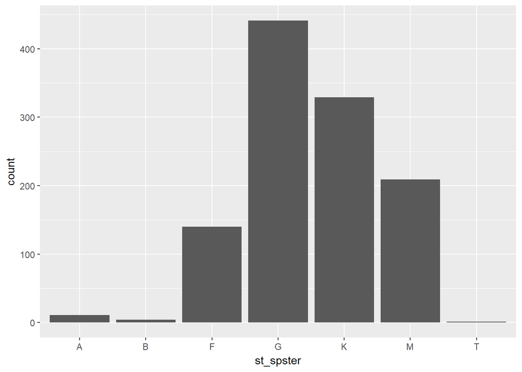

Most stars with exoplanets orbiting them can be lumped in to one of four stellar classifications: F, G, K, or M.

Interestingly, the most common stellar classification is G, which is the same classification as our own sun.

Class M stars are the most common stars in the universe, so it is not surprising that many stars in our dataset are class M – although it is worth noting that despite class M stars prevalence in the universe, they are not the most common stars that host exoplanets (that we’ve discovered).

Class K stars are an intermediary class between G and M stars.

Class F stars are similar in mass to the Sun, but emit more UV radiation.

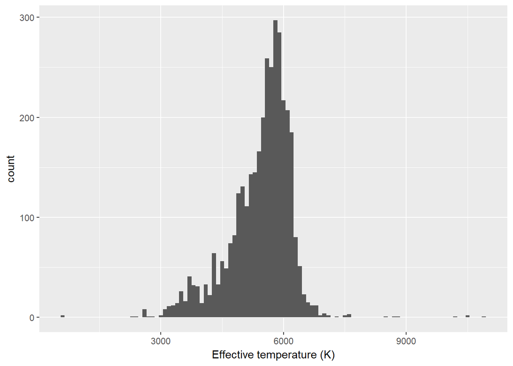

Effective temperature of stars in our dataset form an approximately normal distribution around 6000 K, with a slight skew to the left.

# Univariate Analysis

### What is/are the main feature(s) of interest in your dataset?

Discovery method is perhaps the focal point of this dataset. The transit discovery method seems to have been the most fruitful exoplanet discovery method, which means it’s important to do some analysis of this discovery method. Are there certain planets that this method of discovery is biased toward discovering? If so, what are the features of those planets?

It’s also possible that this method of discovery is *not* biased, but is simply discovering a sample distribution of planets representative of *all* planets that exist in the universe, although testing this notion might be beyond the scope of our analysis.

### What other features in the dataset do you think will help support your investigation into your feature(s) of interest?

The various attributes of the stars in the dataset will help investigate the discovery methods. It’s possible that certain star types are predisposed to certain discovery methods.

Planetary attributes such as mass, density, and radius will give us a good idea of the types of planets each discovery method is more inclined to discover. These attributes can also be compared to attributes of stars to see any relationship that might exist there.

### Did you create any new variables from existing variables in the dataset?

I created a new dataframe which tracks the number of planets in a system. A histogram of the column pl_pnum is not representative of the number of planets in a system because every planet in a system of say 5 planets would have 5 listed as the number of planets in a system. This would mean that a system of 5 planets would add 25 to the histogram plot, rather than just 5.

I attempted to impute some of the null density values using the volume and radius columns, but it turned out that all rows with null density values also have either a null volume or null radius value as well, making density impossible to compute.

### Of the features you investigated, were there any unusual distributions?

I’m surprised by the number of ‘big’ planets in general! Although histograms show a lot of data points near zero, there are still a huge number of data points above 1 Jupiter mass. Jupiter is the *largest* planet in our solar system, which makes it so surprising to see such a large number of planets above 1 Jupiter mass. This makes me think that large planets are generally easier to discover than smaller planets.

### Did you perform any operations on the data to tidy, adjust, or change the form of the data? If so, why did you do this?

I grabbed the first character from the spectral type column. This is because many stars in the dataset were described too precisely for our needs, ie a star might have been listed as type ‘K-IIIbv’ which is a very narrow sub-classification of a type K star. All we care about is the first letter in this column.

I dropped over 100 columns from the dataframe, and created a new dataframe that lists the number of planets in a system without repeating this data as it is in our uncleaned dataframe. I also dropped all data points that weren’t collected via the transit, radial velocity, imaging, or microlensing discovery methods because there was very little data for these discovery methods.

# Bivariate Plots Section

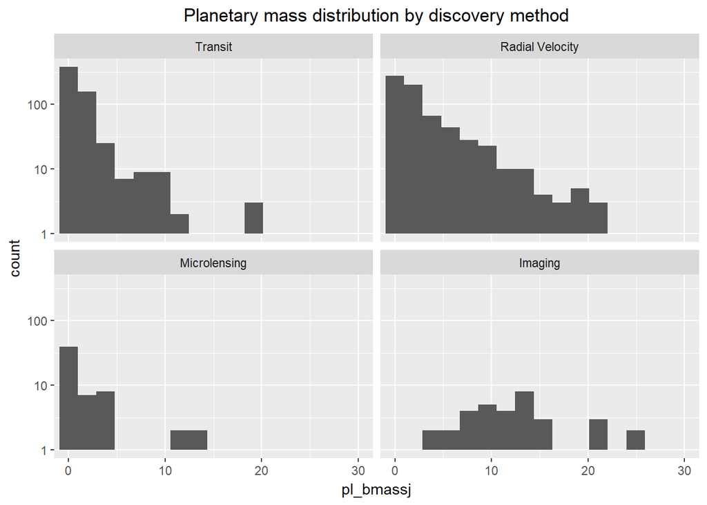

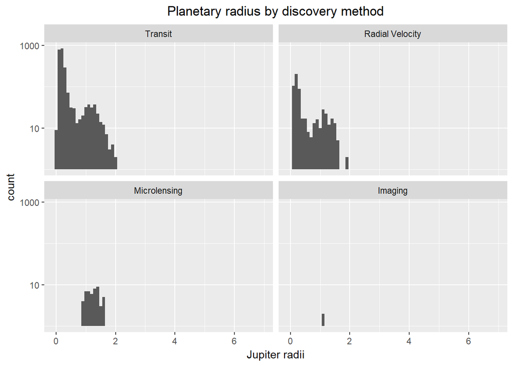

All discovery methods have distributions almost entirely less than 4 Jupiter radii. This is surprising, and seems to suggest that my theory that it’s easier to discovery planets with larger radii is wrong. Again, all y axes are scaled by log 10.

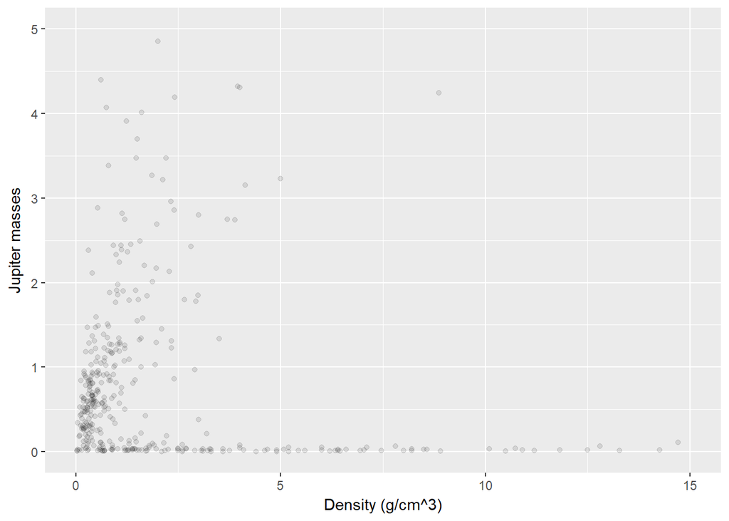

The line of points hugging 0 mass with density between 0 and 15 g/cm^3 is most likely representing terrestrial planets. These planets would have high density due to their rocky composition, but low mass due to size limits (a terrestrial planet has a theoretical size limit of about 2 *earth* radii according to [this study](https://arxiv.org/pdf/1311.0329v1.pdf)). The second plot clearly shows two different groups of planets.

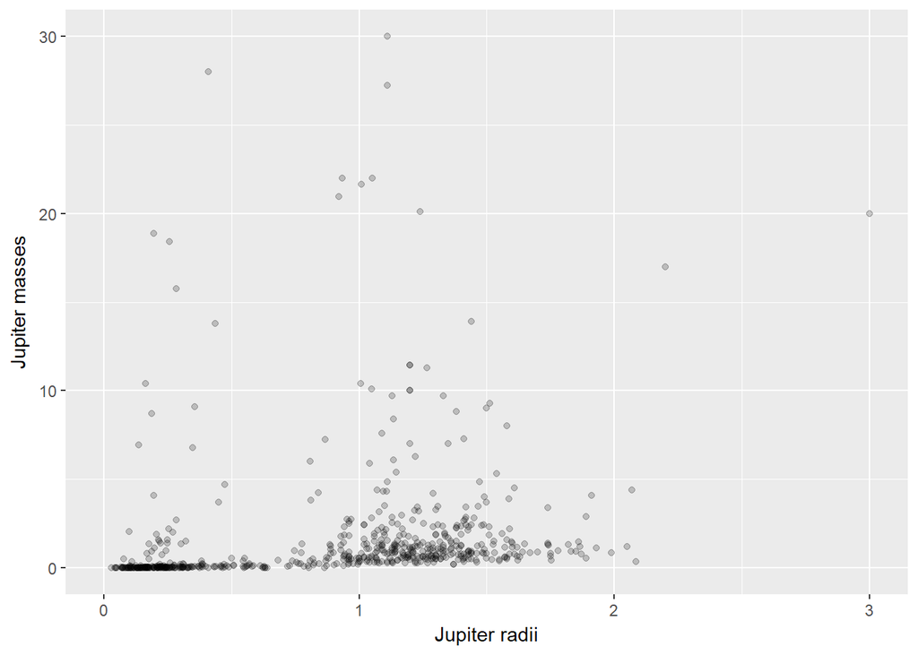

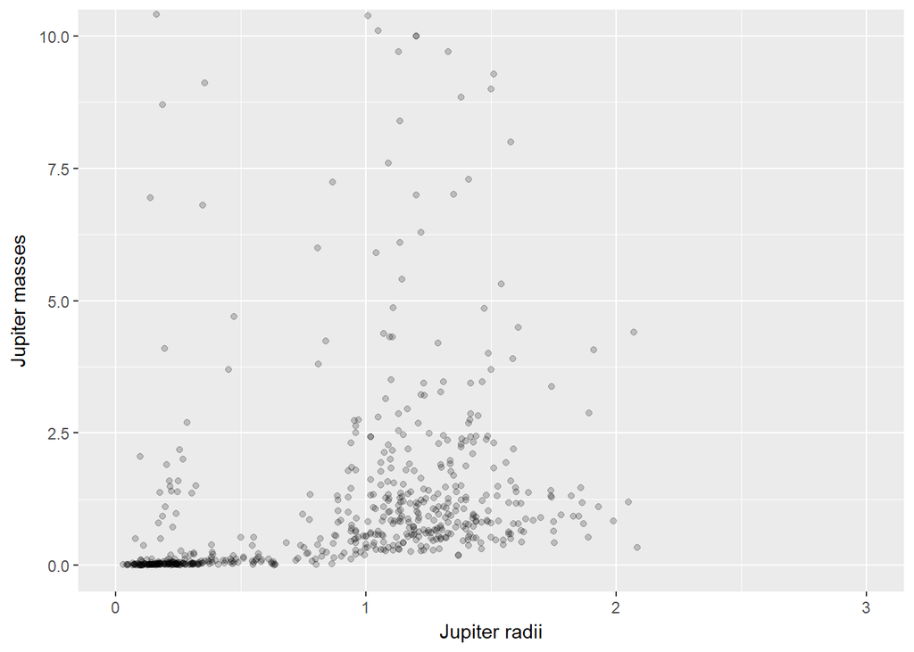

Mass and radius have less of a positive correlation than I would expect. By changing the alpha of points in this plot we can see the large grouping of what I believe are terrestrial planets near 0 Jupiter radii and 0 Jupiter masses. The gaseous planets appear to have a large grouping near 1 Jupiter radius and 1 Jupiter mass, yet a significant number of planets have huge mass that doesn’t follow the trend of other gas planets. This makes me think there are a several distinct groups of planets in our data set. Could this be due to the bias of different discovery methods to discover different types of planets?

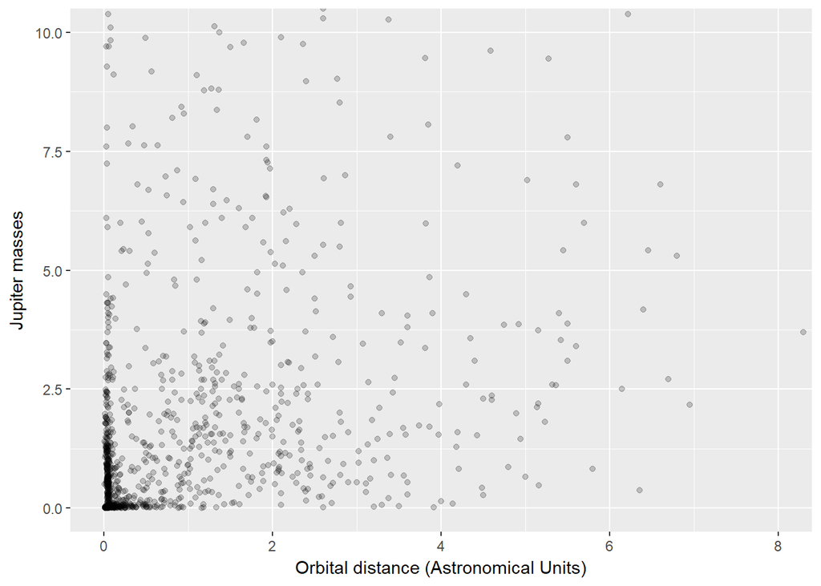

There’s no obvious correlation between a planet’s max orbit and a planet’s mass, but there is an interesting vertical line very close to 0 astronomical units. These are likely gas planets orbiting very close to their star (known as hot Jupiters).

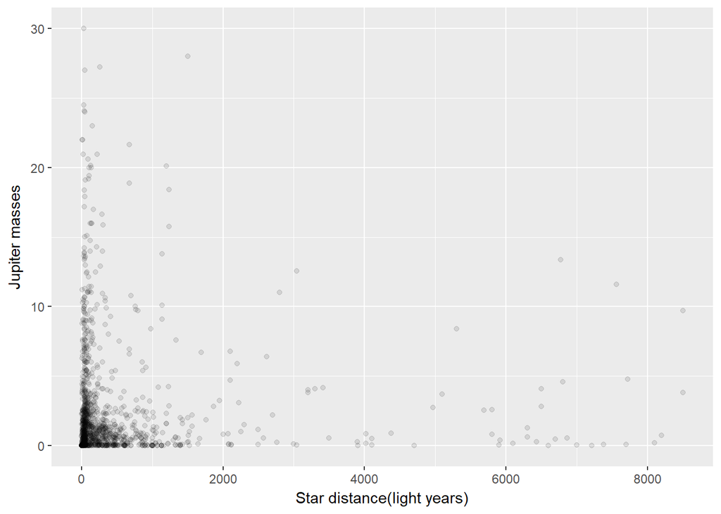

There appears to be a weak negative correlation between star distance and planet mass. This is somewhat counterintuitive because I would expect higher mass planets to be easier to discover than low mass planets particularly when the host star is far away. Perhaps this is explained by limitations in planetary discovery methods at different distances.

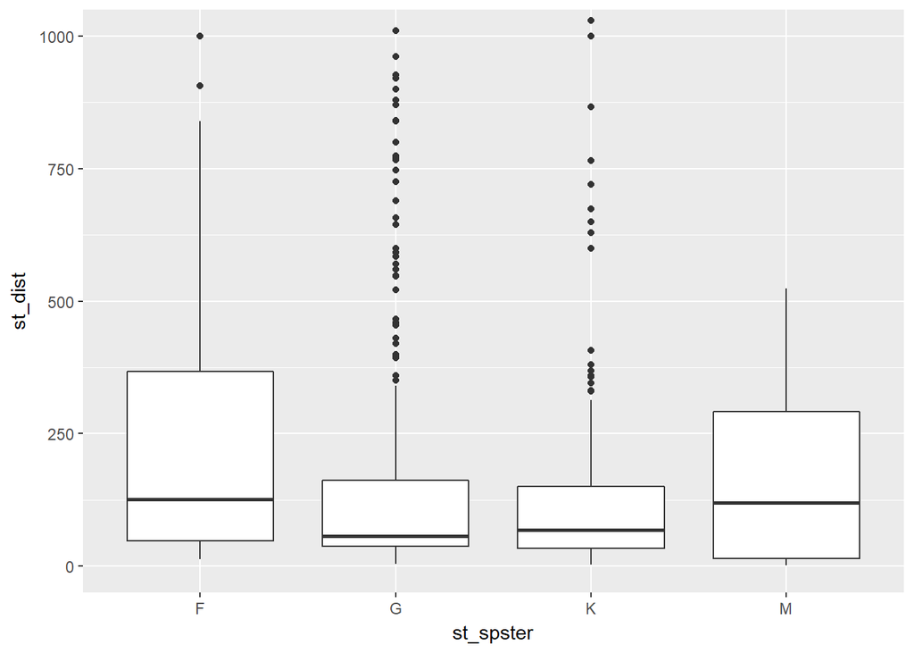

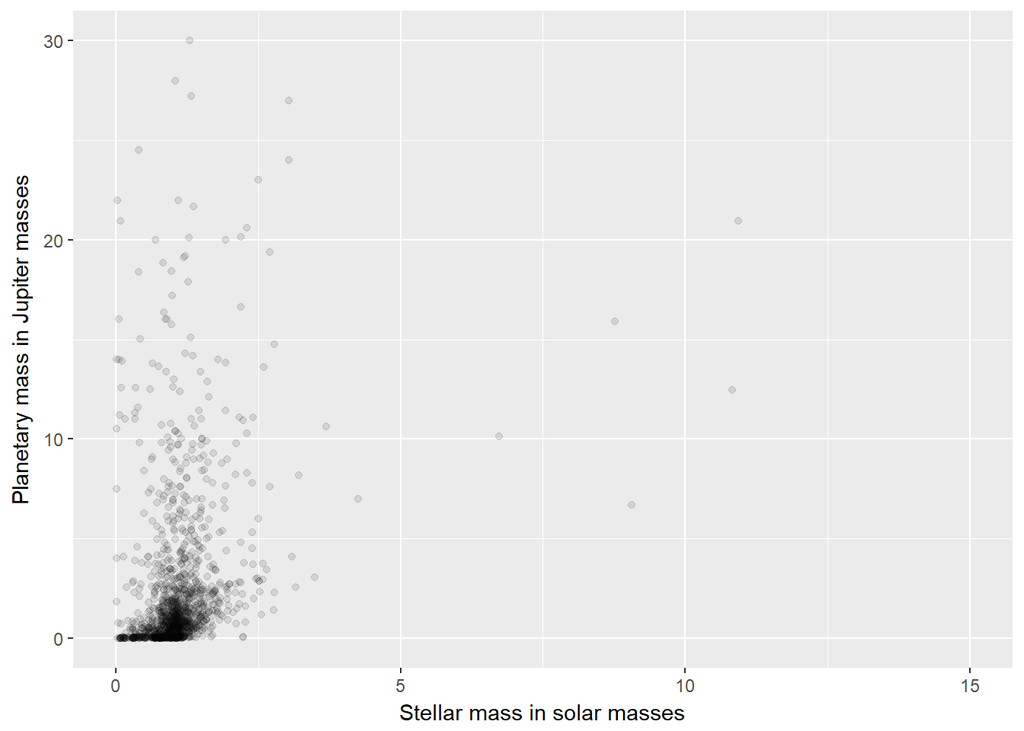

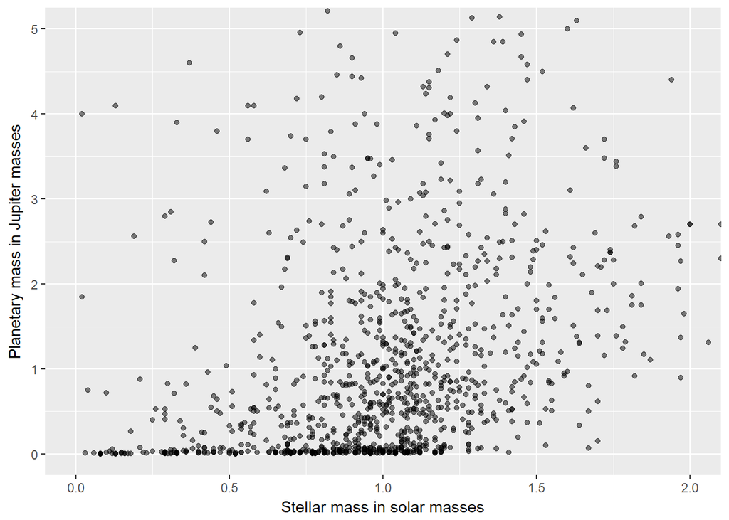

Most stars have mass around 1 solar mass or less. Planetary mass does not appear to be correlated to star mass.

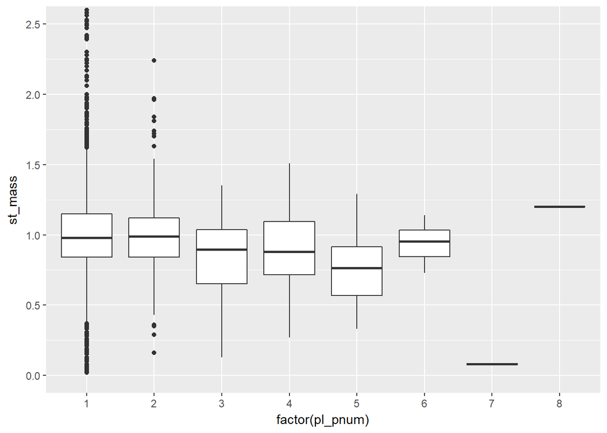

There doesn’t appear to be any significant difference in the mass of a star when compared to the number of planets orbiting a star.

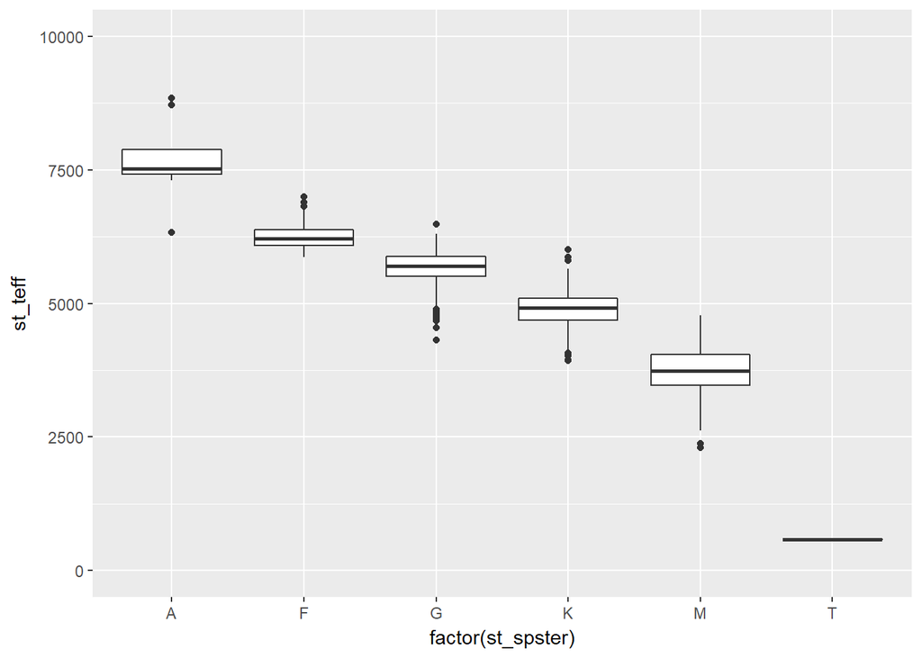

Stars classified later in the alphabet tend to haved lower effective temperatures among stars that have exoplanets orbiting them. This likely has something to do with how stars are classified.

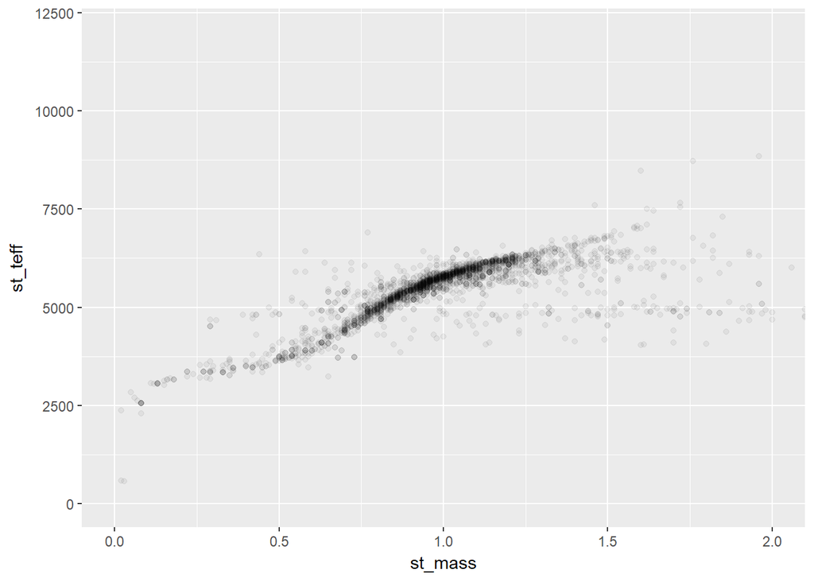

There’s correlation between star mass and star effective temperature. I hesitate to call it strong, but we definitely see tightly packed observations trending upward linearly. This plot is reminiscent of a sigmoid curve – I’d be interested in the physics behind this.

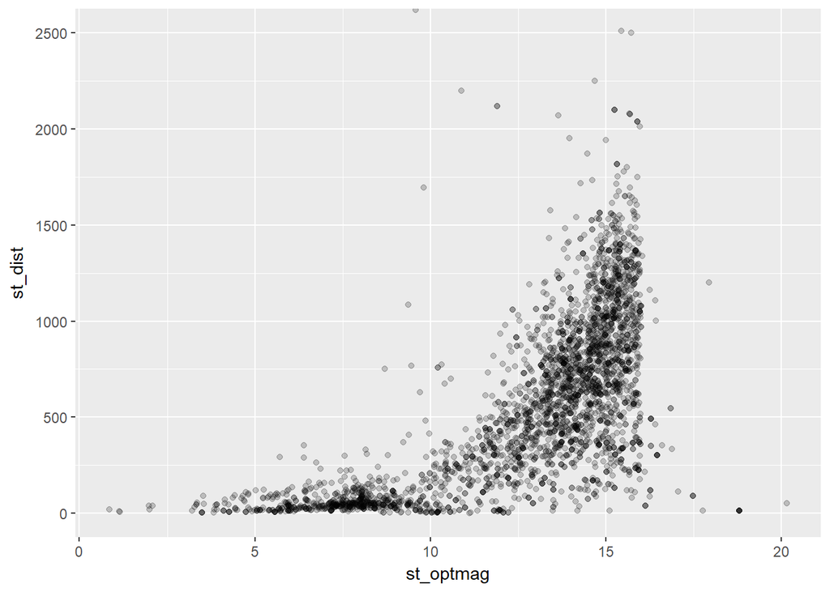

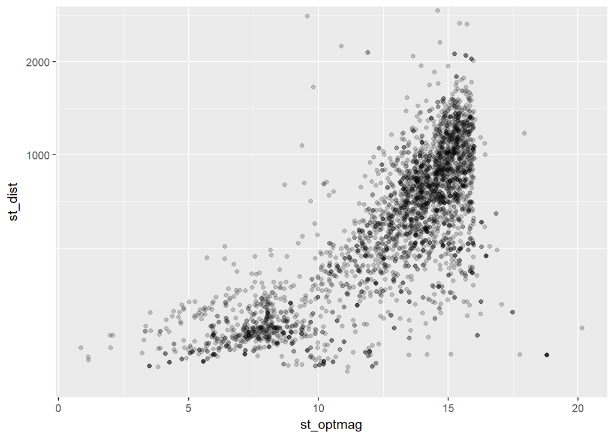

There appears to be some non-linear relationship between a star’s distance from earth and its optical magnitude. I’d guess this is a quadratic relationship because light propagates according to the inverse *square* law. Scaling the y-axis by square root smooths out the relation a little bit, but it’s still not quite linear.

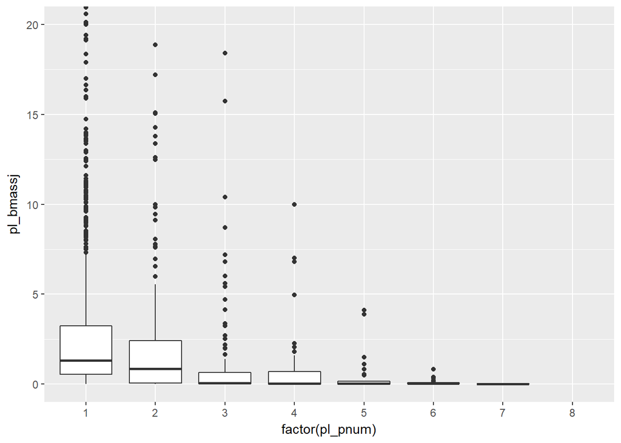

As the number of planets in a system increases, the mass of those planets tends to decrease.

# Bivariate Analysis

### Talk about some of the relationships you observed in this part of the investigation. How did the feature(s) of interest vary with other features in the dataset?

The relationship between planetary mass and planetary radius, as well as between planetary mass and planetary density is not as positievly correlated as expected. One would expect a strong correlation in both scenarios, but there is something going on in mass, radius, and density preventing this. It definitely warrants further investigation. Adding additional variables might definitively explain this.

There’s a weak negative correlation between star distance from earth and planetary mass. I’d expect this to be explained by bias in different discovery methods. Perhaps the methods that are capable of discovering planets very far from earth are biased towards discovering lower mass planets.

### Did you observe any interesting relationships between the other features (not the main feature(s) of interest)?

Adding another variable to the analysis is beginning to tell more of a story. The scatter plot comparing planetary density and planetary mass shows what I believe are terrestrial planets hugging the x axis. I believe these planets are terrestrial because they have low mass and high density, which is what one would expect from a terrestrial planet. Terrestrial planets have low mass due to physical restrictions on their radius.

Most stars in our dataset have about one solar mass. I’m interested to know if there’s something special about stars that have one solar mass to make planets more likely to orbit them, or if this is simply a result of the distribution of all stars’ masses.

### What was the strongest relationship you found?

The relationship between star optical magnitude and the square root of star distance is the strongest relation I found. I believe this is due to light from a star propagating according to the inverse square of a star’s distance.

# Multivariate Plots Section

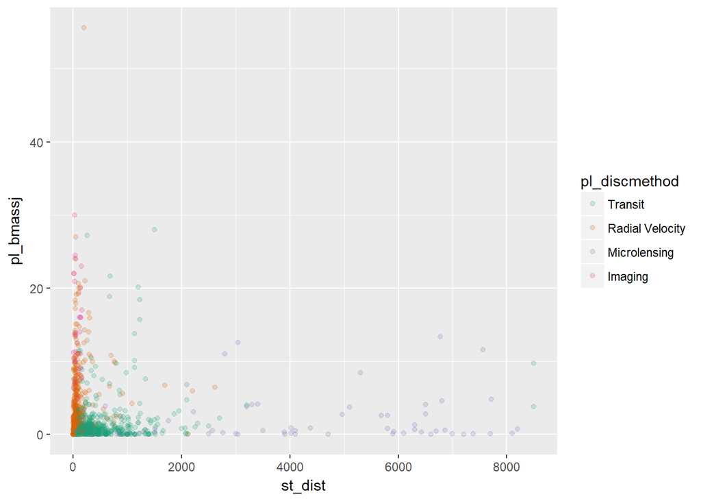

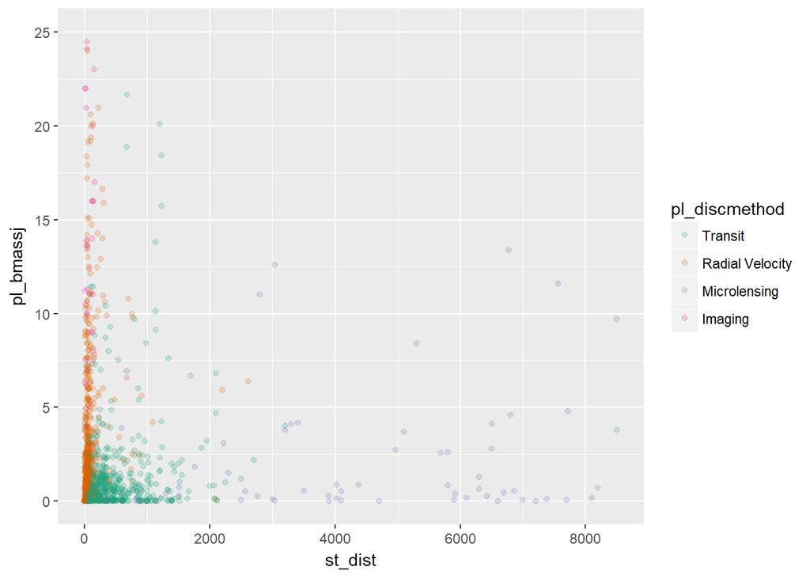

This plot has some fascinating qualities! Almost every single planet discovered more than 3000 light years away was discovered through microlensing! Radial velocity seems to be the most common discovery method for relatively close planets (and seems to have no problem discovering high mass planets), while the transit method seems to easily discover planets a little further away, but less than 2000 light years away. Planets discovered via transit also seem to have lower mass than planets discovered via radial velocity. Planets discovered via imaging are generally very near earth, and can have relatively high mass.

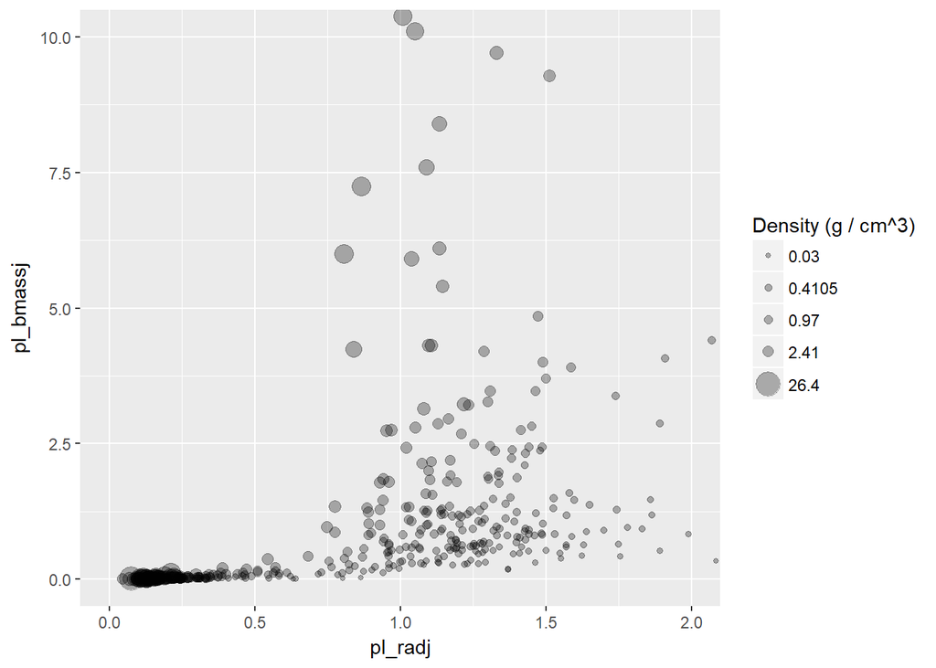

This plot gives us a better idea of the relationship between planetary radius, mass, and density. Density is represented by the size of the points here, making it apparent that planets with high density are clustered near 0 Jupiter masses and 0 Jupiter radii. This cluster in the bottom left of the plot almost certainly represents terrestrial planets.